# HDAC9 variant vs RNAseq

Accompanying ‘Plaque expression levels of HDAC9 in association with plaque vulnerability traits and secondary vascular events in patients undergoing carotid endarterectomy, an analysis in the Athero-EXPRESS Biobank.’

[Sander W. van der Laan, PhD](https://vanderlaan.science) | s.w.vanderlaan@gmail.com.

2024-08-18

# General Setup

```
Create a new analysis directory...
```

```r
source(paste0(PROJECT_loc, "/scripts/functions.R"))
```

```r
source(paste0(PROJECT_loc, "/scripts/pack01.packages.R"))
```

```
* General packages...
```

[output not shown]

# Background

This notebook contains figures to plot the *HDAC9* variant vs *HDAC9* expression of the project “Plaque expression levels of *HDAC9* in association with plaque vulnerability traits and secondary vascular events in patients undergoing carotid endarterectomy: an analysis in the Athero-EXPRESS Biobank.”.

# Loading data

```r
# load(paste0(PROJECT_loc, "/",Today,".",PROJECTNAME,".bulkRNAseq.main_analysis.RData"))
load(paste0(PROJECT_loc, "/20220319.",PROJECTNAME,".bulkRNAseq.main_analysis.RData"))
```

```r
source("/Users/slaan3/git/CirculatoryHealth/AE_20211201_YAW_SWVANDERLAAN_HDAC9/scripts/local.system.R")
```

```
Create a new analysis directory...
```

```r
Today = format(as.Date(as.POSIXlt(Sys.time())), "%Y%m%d")
Today.Report = format(as.Date(as.POSIXlt(Sys.time())), "%A, %B %d, %Y")
```

# Extract genetic data

Here we extract the relevant genetic data for rs2107595 - the *HDAC9* variant.

We produce a `.gen`-file which retains the probabilities and a `.ped`-file which contains hardcoded genotypes. We ran `convert_impute2dosage.pl` to convert the `.gen`-files to `.dosages`.

```bash
AEGS_LOC="/Users/slaan3/PLINK/_AE_ORIGINALS/AEGS_COMBINED_EAGLE2_1000Gp3v5HRCr11"
PLINK2="/Users/slaan3/bin/plink2"
HERCULES_loc="/Users/slaan3/git/swvanderlaan/HerculesToolKit/_imputation"
PERL="/Users/slaan3/miniforge3/bin/perl"

$PLINK2 --bgen $AEGS_LOC/aegs.qc.1kgp3hrcr11.idfix.rsid.8bit.chr7.bgen 'ref-first' --sample $AEGS_LOC/aegs.qc.1kgp3hrcr11.idfix.8bit.chr7.sample --snp rs2107595 --export 'oxford-v2' --out $AEGS_LOC/aegs.qc.1kgp3hrcr11.idfix.rsid.8bit.chr7.rs2107595

$PLINK2 --bgen $AEGS_LOC/aegs.qc.1kgp3hrcr11.idfix.rsid.8bit.chr7.bgen 'ref-first' --sample $AEGS_LOC/aegs.qc.1kgp3hrcr11.idfix.8bit.chr7.sample --snp rs2107595 --export 'ped' --out $AEGS_LOC/aegs.qc.1kgp3hrcr11.idfix.rsid.8bit.chr7.rs2107595

$PERL $HERCULES_loc/convert_impute2dosage.pl $AEGS_LOC/aegs.qc.1kgp3hrcr11.idfix.rsid.8bit.chr7.rs2107595.gen NORM $AEGS_LOC/aegs.qc.1kgp3hrcr11.idfix.rsid.8bit.chr7.rs2107595.dose
```

[output not shown]

[output cut: 6890 more lines]

[output not shown]

# Load genetic data

Now we’re ready to load the genetic data. Firs the sample data.

```r
aegs_sample_meta_temp <- fread(paste0(MICHIMP_loc,"/aegs.qc.1kgp3hrcr11.chr7.sample"))
aegs_sample_meta <- aegs_sample_meta_temp %>%
  filter(SampleID!='0')
aegs_sample_meta$Index <- row.names(aegs_sample_meta)
rm(aegs_sample_meta_temp)
```

Next, the dosage data.

```r
hdac9_dose_temp <- as.data.table(t(fread(paste0(MICHIMP_loc,"/aegs.qc.1kgp3hrcr11.idfix.rsid.8bit.chr7.rs2107595.dose"))))
names(hdac9_dose_temp)[names(hdac9_dose_temp) == "V1"] <- "rs2107595_dose"
hdac9_dose <- hdac9_dose_temp %>%
  filter(rs2107595_dose!='A' & rs2107595_dose!='G' & rs2107595_dose!='rs2107595')
hdac9_dose$Index <- row.names(hdac9_dose)
rm(hdac9_dose_temp)
```

Let’s match this with the sample data; the order in the dosage data is the order in the sample data.

```r
aegs_sample_hdac9_dose <- aegs_sample_meta %>%
  left_join(hdac9_dose, by = c("Index" = "Index"))
```

Now, we’ll load the hardcoded genotypes. The A-allele is the Reference allele; the B-allele is the Alternative allele.

```r
hdac9_geno <- fread(paste0(MICHIMP_loc,"/aegs.qc.1kgp3hrcr11.idfix.rsid.8bit.chr7.rs2107595.ped"))
names(hdac9_geno)[names(hdac9_geno) == "V2"] <- "SampleID"
names(hdac9_geno)[names(hdac9_geno) == "V7"] <- "Ref_A_allele"
names(hdac9_geno)[names(hdac9_geno) == "V8"] <- "Alt_B_allele"
hdac9_geno$V1 <- NULL
hdac9_geno$V3 <- NULL
hdac9_geno$V4 <- NULL
hdac9_geno$V5 <- NULL
hdac9_geno$V6 <- NULL
```

We’ll match that with the sample data and remove the intermediate datasets. At the same time we create a new variable which holds the genotypes.

```r
aegs_sample_hdac9_dose_geno <- aegs_sample_hdac9_dose %>%
  left_join(hdac9_geno, by = c("SampleID" = "SampleID"))

aegs_sample_hdac9_dose_geno$genotype <- paste0(aegs_sample_hdac9_dose_geno$Ref_A_allele,aegs_sample_hdac9_dose_geno$Alt_B_allele)

rm(aegs_sample_hdac9_dose, hdac9_geno, aegs_sample_meta, hdac9_dose)
```

We’ll keep the genetic map too.

```r
hdac9_geno_map <- fread(paste0(MICHIMP_loc,"/aegs.qc.1kgp3hrcr11.idfix.rsid.8bit.chr7.rs2107595.map"))
names(hdac9_geno_map)[names(hdac9_geno_map) == "V1"] <- "chr"
names(hdac9_geno_map)[names(hdac9_geno_map) == "V2"] <- "rsid"
names(hdac9_geno_map)[names(hdac9_geno_map) == "V3"] <- "cm"
names(hdac9_geno_map)[names(hdac9_geno_map) == "V4"] <- "bp"
```

We also need the KeyTable to match the `SampleID` to the `STUDY_NUMBER`; we need this to match with the gene expression data.

```r
cat("* get Athero-Express Genomics Study keys...")
```

```
* get Athero-Express Genomics Study keys...
```

```r
AEGS123.sampleList.keytable <- fread(paste0(AEGSQC_loc, "/QC/SELECTIONS/20200419.QC.AEGS123.sampleList.keytable.txt"))

dim(AEGS123.sampleList.keytable)
```

```
[1] 2124   25
```

Let’s match this to our new genetic dataset.

```r
temp <- subset(aegs_sample_hdac9_dose_geno, select = c("SampleID", "rs2107595_dose", "genotype", "Ref_A_allele", "Alt_B_allele"))
aegs_sample_hdac9_dose_geno_key <- AEGS123.sampleList.keytable %>%
  left_join(temp, by = c("ID_1" = "SampleID"))
rm(temp)
```

# Match the gene expression data

Let’s match the gene expression data to the genetic data.

```r
aegs_sample_hdac9_dose_geno_key$STUDY_NUMBER <- paste("ae",aegs_sample_hdac9_dose_geno_key$STUDY_NUMBER, sep = "")

AERNASE.clin.hdac9.geno <- AERNASE.clin.hdac9 %>%
  left_join(aegs_sample_hdac9_dose_geno_key, by = c("STUDY_NUMBER" = "STUDY_NUMBER"))
```

# Plotting

Here plot the hardcoded genotypes vs. the gene expression of *HDAC9*.

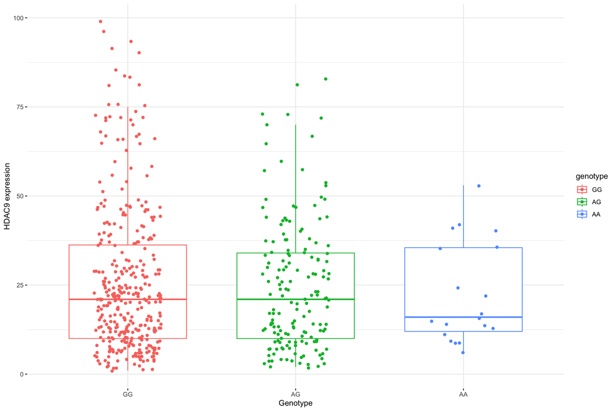

```r
library(ggpubr)
temp <- subset(AERNASE.clin.hdac9.geno, !is.na(genotype) & !is.na(HDAC9) & genotype != "00" & HDAC9 < 100)
temp$HDAC9_norm <- scale(temp$HDAC9)
ggpubr::ggboxplot(data = temp,
                  x = "genotype", y = "HDAC9",
                  color = "genotype", #palette = uithof_color_legend,
                  add = "jitter",
                  xlab = "Genotype", ylab = "HDAC9 expression",
                  ggtheme = ggplot2::theme_minimal())
```

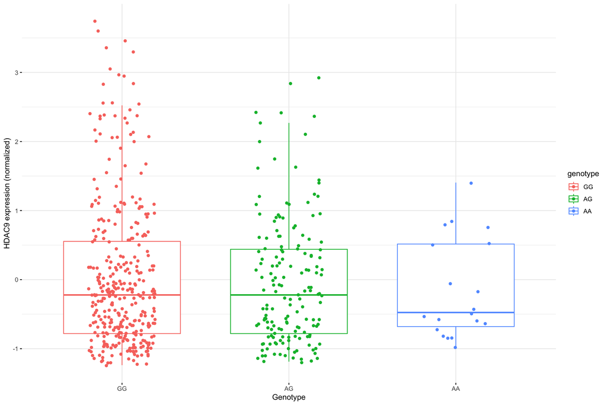

```r
ggsave(paste0(PLOT_loc, "/", Today, ".",TRAIT_OF_INTEREST,".HDAC9_variant_hardcoded_vs_HDAC9_expression_sm100.png"), width = 12, height = 8, plot = last_plot())
ggsave(paste0(PLOT_loc, "/", Today, ".",TRAIT_OF_INTEREST,".HDAC9_variant_hardcoded_vs_HDAC9_expression_sm100.pdf"), width = 12, height = 8, plot = last_plot())
ggpubr::ggboxplot(data = temp,
                  x = "genotype", y = "HDAC9_norm",
                  color = "genotype", #palette = uithof_color_legend,
                  add = "jitter",
                  xlab = "Genotype", ylab = "HDAC9 expression (normalized)",
                  ggtheme = ggplot2::theme_minimal())
```

```r
ggsave(paste0(PLOT_loc, "/", Today, ".",TRAIT_OF_INTEREST,".HDAC9_variant_hardcoded_vs_HDAC9_expression_sm100_normalized.png"), width = 12, height = 8, plot = last_plot())
ggsave(paste0(PLOT_loc, "/", Today, ".",TRAIT_OF_INTEREST,".HDAC9_variant_hardcoded_vs_HDAC9_expression_sm100_normalized.pdf"), width = 12, height = 8, plot = last_plot())
rm(temp)
```

Here plot the dosages vs. the gene expression of *HDAC9*.

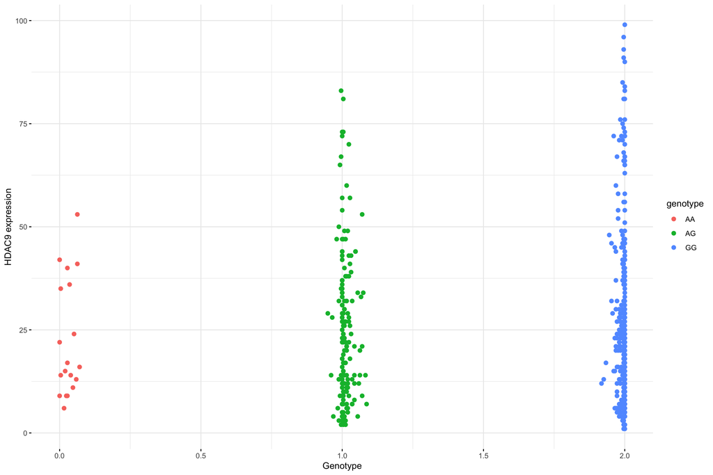

```r
library(ggpubr)
temp <- subset(AERNASE.clin.hdac9.geno, !is.na(genotype) & !is.na(HDAC9) & genotype != "00" & HDAC9 < 100)
temp$HDAC9_norm <- scale(temp$HDAC9)
ggpubr::ggscatter(data = temp,
                  x = "rs2107595_dose", y = "HDAC9",
                  color = "genotype", #palette = uithof_color_legend,
                  # add = "jitter",
                  xlab = "Genotype", ylab = "HDAC9 expression",
                  ggtheme = ggplot2::theme_minimal())
```

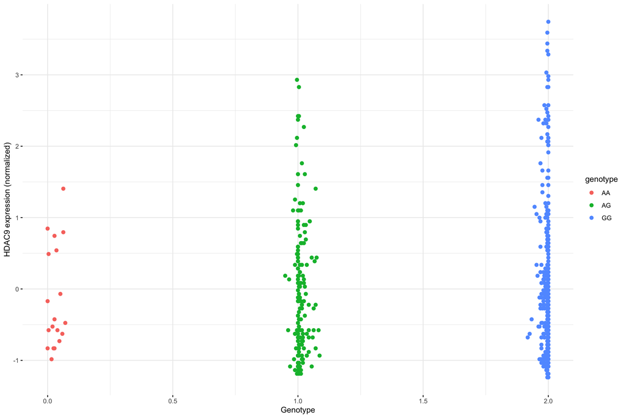

```r
ggsave(paste0(PLOT_loc, "/", Today, ".",TRAIT_OF_INTEREST,".HDAC9_variant_dose_vs_HDAC9_expression_sm100.png"), width = 12, height = 8, plot = last_plot())
ggsave(paste0(PLOT_loc, "/", Today, ".",TRAIT_OF_INTEREST,".HDAC9_variant_dose_vs_HDAC9_expression_sm100.pdf"), width = 12, height = 8, plot = last_plot())
ggpubr::ggscatter(data = temp,
                  x = "rs2107595_dose", y = "HDAC9_norm",
                  color = "genotype", #palette = uithof_color_legend,
                  # add = "jitter",
                  xlab = "Genotype", ylab = "HDAC9 expression (normalized)",
                  ggtheme = ggplot2::theme_minimal())
```

```r
ggsave(paste0(PLOT_loc, "/", Today, ".",TRAIT_OF_INTEREST,".HDAC9_variant_dose_vs_HDAC9_expression_sm100_normalized.png"), width = 12, height = 8, plot = last_plot())
ggsave(paste0(PLOT_loc, "/", Today, ".",TRAIT_OF_INTEREST,".HDAC9_variant_dose_vs_HDAC9_expression_sm100_normalized.pdf"), width = 12, height = 8, plot = last_plot())
rm(temp)
```

# Session information

```
Version:      v1.0.0
Last update:  2024-08-17
Written by:   Sander W. van der Laan (s.w.vanderlaan-2[at]umcutrecht.nl).
Description:  Script to plot HDAC9 genotypes vs. HDAC9 expression from the Ather-Express Biobank Study.
Minimum requirements: R version 3.5.2 (2018-12-20) -- 'Eggshell Igloo', macOS Mojave (10.14.2).

**MoSCoW To-Do List**
The things we Must, Should, Could, and Would have given the time we have.
_M_

_S_

_C_

_W_

**Changes log**
* v1.0.0 Inital version.
```

# Saving environment

```r
save.image(paste0(PROJECT_loc, "/",Today,".",PROJECTNAME,".HDAC9_variant_vs_RNAseq.RData"))
```

| <sup>© 1979-2023 Sander W. van der Laan \| s.w.vanderlaan[at]gmail.com \| vanderlaan.science.</sup> \| |
| --- |